# SEN1221 Statistical Analysis of Choice Behaviour

## `Session Lab 03:`

## `Combining machine learning and discrete choice models`

**Delft University of Technology**  
**Q2 2023**  
**Instructor:** Sander van Cranenburgh  
**TA:** Gabriel Nova

### `Application: Modelling neighbourhood choices`

In this lab session, we will use neighbourhood location choice data of lab session 1: Stated Choice (SC) data, which was collected between 2017 and 2018 in four European cities: Hanover, Mainz, Bern, and Zurich. During this lab session, you will train a neural network and a hybrid choices model to uncover people's preferences over residential location choice attributes, such as the distance to the city centre and the share of foreigners in their neighbourhood.

[figure not shown]

**`This lab consists of 4 parts and has 5 exercises`**

**Part 1**: Data preparation

**Part 2**: The linear-additive RUM-MNL model

- Excerise 1: "Willigness to pay for grocery stores"

**Part 3**: The MultiLayer Perceptron

- Excerise 2: "Training the MLP model"
- Excerise 3: "Adding the socio-demographic features"

**Part 4**: The L-MNL model

- Excerise 4: "Feature MLP"
- Excerise 5: "Forescasting using L-MNL model"

#### `Import packages`

```python
# Biogeme
import biogeme.database as db
import biogeme.biogeme as bio
from biogeme import models
from biogeme.expressions import Beta, Variable, log

# Import required Python packages and modules
import pandas as pd
import matplotlib.pyplot as plt
import numpy as np
from pathlib import Path

# Scikit-learn
from sklearn.preprocessing import StandardScaler

#Pytorch
import torch
import torch.nn as nn
import torch.optim as optim
from torch.utils.data import DataLoader, TensorDataset

# Pandas setting to show all columns when displaying a pandas dataframe
pd.set_option('display.max_columns', None)
```

### `1. Load and explore the data set`

`i. Set up the workspace and load the database`

```python
# Create that path to the data file
data_path = Path(f'data/choice_data.dat')

# Load mode choice data into a pandas DataFrame
df = pd.read_csv(data_path, sep='\t')

# Show the column names
print(df.columns)
```

```
Index(['ID', 'TASK_ID', 'STORES1', 'TRANSPORT1', 'CITY1', 'NOISE1', 'GREEN1',
       'FOREIGN1', 'STORES2', 'TRANSPORT2', 'CITY2', 'NOISE2', 'GREEN2',
       'FOREIGN2', 'STORES3', 'TRANSPORT3', 'CITY3', 'NOISE3', 'GREEN3',
       'FOREIGN3', 'CHOICE', 'RESPCITY', 'WOMAN', 'AGE', 'ENVCONC', 'EDUYEARS',
       'RESPFOREIGN', 'HOMEOWNER', 'CAROWNER', 'JOB', 'NONWESTERN', 'WESTERN'],
      dtype='object')
```

**Description of variables**

The number concatenated to the variable refers to the alternative. Hence, `STORES1` is the column containing the attribute levels of alternative 1 for attribute STORES.

| Variable | Description | Type/Levels |
| --- | --- | --- |
| `ID` | This is the ID number of the respondent | Integer |
| `TASK_ID` | This is the number of the respondent's task of choice | Integer |
| `STORES` | Distance to grocery store in walking minutes | 2 Min., 5 Min., 10 Min., 15 Min. |
| `TRANSPORT` | Distance to public transportation in walking minutes | 2 Min., 5 Min., 10 Min., 15 Min. |
| `CITY` | Distance to city centre in km | Below 1 km, 1 to 2 km, 3 to 4 km, over 4 km |
| `NOISE` | Street traffic noise | 1 = None, 2 = Little, 3 = Meduim, 4 = High |
| `GREEN` | Green areas in residential area | 1 = None, 2 = Few, 3 = Some, 4 = Many |
| `FOREIGN` | Share of foreigners in residential areas | 0.10, 0.20, 0.30, 0.40 |
| `CHOICE` | Indicates the choice. | Integer |
| `RESPCITY` | Indicates the city. 1 = Mainz, 2 = Hanover, 3 = Bern, 4 = Zurich | Categorical |
| `WOMAN` | Indicates 1 if woman and 0 otherwise | Binary |
| `AGE` | Age in years | Integer |
| `ENVCONC` | Environmental concern from 1 to 5, with 5 being the highest degree of concern | Ordinal |
| `EDUYEARS` | Number of years in education | Numeric |
| `RESPFOREIGN` | 1 if the respondent is a foreigner, 0 otherwise | Binary |
| `HOMEOWNER` | Indicates 1 if the respondent is a home owner and 0 otherwise | Binary |
| `CAROWNER` | Indicates 1 if the respondent is a car owner and 0 otherwise | Binary |
| `JOB` | 1 if the respondent is working, 0 otherwise | Binary |
| `NONWESTERN` | 1 if the respondent is non-western, 0 otherwise | Binary |
| `WESTERN` | 1 if the respondent is western, 0 otherwise | Binary |

```python
# Define the relevant features of the alternatives
features_alt =   ['STORES1', 'TRANSPORT1', 'CITY1', 'NOISE1', 'GREEN1', 'FOREIGN1',
                  'STORES2', 'TRANSPORT2', 'CITY2', 'NOISE2', 'GREEN2', 'FOREIGN2',
                  'STORES3', 'TRANSPORT3', 'CITY3', 'NOISE3', 'GREEN3', 'FOREIGN3']

# Define the relevant socio-economic variables
sociovars = ['AGE','WOMAN','HOMEOWNER','CAROWNER','RESPCITY', 'JOB','ENVCONC', 'EDUYEARS', 'RESPFOREIGN', 'NONWESTERN', 'WESTERN']
```

Handle the missing data

```python
# Replace 9999 with NaN
df = df.replace(99999, np.nan)

# Remove rows with missing data in the relevant features
df = df.dropna(subset=sociovars, how='any')
```

Recode categorical socio demographic variables

```python
# Create a dataframe with the relevant socio demographic variables
df_sociovars  = df[sociovars].astype(int)

# Recode 'AGE' in three categorical levels.
df_sociovars.loc[(      df_sociovars['AGE'] < 25), 'AGE'] = 1
df_sociovars.loc[(25 <= df_sociovars['AGE']     ) &
                 (      df_sociovars['AGE'] < 60), 'AGE'] = 2
df_sociovars.loc[(60 <= df_sociovars['AGE']     ), 'AGE'] = 3

# Recode 'EDUYEARS' in three categorical levels.
df_sociovars.loc[(      df_sociovars['EDUYEARS'] < 10), 'EDUYEARS'] = 1
df_sociovars.loc[(10 <= df_sociovars['EDUYEARS']     ) &
                 (      df_sociovars['EDUYEARS'] < 14), 'EDUYEARS'] = 2
df_sociovars.loc[(14 <= df_sociovars['EDUYEARS']     ), 'EDUYEARS'] = 3

# Recode 'ENVCONC' in three categorical levels.
df_sociovars.loc[(     df_sociovars['ENVCONC'] < 3), 'ENVCONC'] = 1
df_sociovars.loc[(3 <= df_sociovars['ENVCONC']    ) &
                 (     df_sociovars['ENVCONC'] < 4), 'ENVCONC'] = 2
df_sociovars.loc[(4 <= df_sociovars['ENVCONC']    ), 'ENVCONC'] = 3

# Convert categorical variables to dummy variables using pd.get_dummies()
df_sociovars = pd.get_dummies(data = df_sociovars, prefix = sociovars, prefix_sep='_', columns = sociovars, drop_first = True, dtype=int)

# Create a list of the names of the socio demographic variables
features_socio = df_sociovars.columns.tolist()

# Show the first few rows of the dataframe
df_sociovars.head()
```

|  | AGE_2 | AGE_3 | WOMAN_1 | HOMEOWNER_1 | CAROWNER_1 | RESPCITY_2 | RESPCITY_3 | RESPCITY_4 | JOB_1 | ENVCONC_2 | ENVCONC_3 | EDUYEARS_2 | EDUYEARS_3 | RESPFOREIGN_1 | NONWESTERN_1 | WESTERN_1 |
| --- | --- | --- | --- | --- | --- | --- | --- | --- | --- | --- | --- | --- | --- | --- | --- | --- |
| 0 | 1 | 0 | 0 | 0 | 0 | 0 | 1 | 0 | 0 | 1 | 0 | 0 | 1 | 0 | 0 | 0 |
| 1 | 1 | 0 | 0 | 0 | 0 | 0 | 1 | 0 | 0 | 1 | 0 | 0 | 1 | 0 | 0 | 0 |
| 2 | 1 | 0 | 0 | 0 | 0 | 0 | 1 | 0 | 0 | 1 | 0 | 0 | 1 | 0 | 0 | 0 |
| 3 | 1 | 0 | 0 | 0 | 0 | 0 | 1 | 0 | 0 | 1 | 0 | 0 | 1 | 0 | 0 | 0 |
| 4 | 1 | 0 | 1 | 0 | 1 | 1 | 0 | 0 | 1 | 0 | 1 | 0 | 1 | 1 | 0 | 0 |

Finally, create the dataframe for training, containing the 'ID', 'CHOICE', attributes and dummy-coded socio-demographic variables

```python
# Concatenate the socio demographic variables with the relevant features of the alternatives
df = pd.concat([df[['ID', 'CHOICE'] + features_alt], df_sociovars], axis=1)

# Show the first few rows of the dataframe
df.head()
```

|  | ID | CHOICE | STORES1 | TRANSPORT1 | CITY1 | NOISE1 | GREEN1 | FOREIGN1 | STORES2 | TRANSPORT2 | CITY2 | NOISE2 | GREEN2 | FOREIGN2 | STORES3 | TRANSPORT3 | CITY3 | NOISE3 | GREEN3 | FOREIGN3 | AGE_2 | AGE_3 | WOMAN_1 | HOMEOWNER_1 | CAROWNER_1 | RESPCITY_2 | RESPCITY_3 | RESPCITY_4 | JOB_1 | … |
| --- | --- | --- | --- | --- | --- | --- | --- | --- | --- | --- | --- | --- | --- | --- | --- | --- | --- | --- | --- | --- | --- | --- | --- | --- | --- | --- | --- | --- | --- | --- |
| 0 | 2 | 1 | 10 | 5 | 1 | 2 | 2 | 0.4 | 15 | 10 | 2 | 3 | 3 | 0.1 | 2 | 15 | 4 | 4 | 4 | 0.2 | 1 | 0 | 0 | 0 | 0 | 0 | 1 | 0 | 0 | … |
| 1 | 2 | 2 | 15 | 5 | 4 | 4 | 1 | 0.1 | 2 | 10 | 5 | 1 | 2 | 0.2 | 5 | 15 | 1 | 2 | 3 | 0.3 | 1 | 0 | 0 | 0 | 0 | 0 | 1 | 0 | 0 | … |
| 2 | 2 | 3 | 10 | 15 | 1 | 3 | 1 | 0.4 | 15 | 2 | 2 | 4 | 2 | 0.1 | 2 | 5 | 4 | 1 | 3 | 0.2 | 1 | 0 | 0 | 0 | 0 | 0 | 1 | 0 | 0 | … |
| 3 | 2 | 2 | 15 | 15 | 5 | 4 | 4 | 0.4 | 2 | 2 | 1 | 1 | 1 | 0.1 | 5 | 5 | 2 | 2 | 2 | 0.2 | 1 | 0 | 0 | 0 | 0 | 0 | 1 | 0 | 0 | … |
| 4 | 3 | 2 | 15 | 5 | 5 | 1 | 3 | 0.4 | 2 | 10 | 1 | 2 | 4 | 0.1 | 5 | 15 | 2 | 3 | 1 | 0.2 | 1 | 0 | 1 | 0 | 1 | 1 | 0 | 0 | 1 | … |

`ii. Split the data in a test and train set`

```python
# Set a seed for reproducibilty
np.random.seed(100)
df['draw']=float('nan')
for i in df['ID'].unique():
    num_obs = len(df.loc[df['ID']==i,'draw'])
    df.loc[df['ID']==i,'draw']= np.repeat(np.random.uniform(0,1,1),num_obs)

# Put 80% of the data in the training set and 20% in the test set
df_train = df.loc[df['draw']< 0.8,:].copy()
df_test  = df.loc[df['draw']>=0.8,:].copy()

# Number of observations in the training and test sets
num_obs_train = len(df_train)
num_obs_test  = len(df_test)

print(f'Number of individuals in the df_train and df_test: \t{df_train.ID.nunique()}  {df_test.ID.nunique()} ')
print(f'Number of observations in the df_train and df_test: \t{len(df_train)} {len(df_test)} ')
```

```
Number of individuals in the df_train and df_test: 	1825  423
Number of observations in the df_train and df_test: 	7300 1692
```

`iii. Scaling the features`  
To efficiently train ANNs it strongly recommended to scale (a.k.a. normalise) the features. There are several ways to scale your data. A commonly used scaler of sk-learn is called 'StandardScaler'. This scaler normalises the variance and shift the location of the distribution to zero, see https://scikit-learn.org/stable/modules/generated/sklearn.preprocessing.StandardScaler.html

```python
# Create X_train and X_test
x_train = df_train[features_alt + features_socio]
x_test  = df_test [features_alt + features_socio]

# Initialize the scaler object
scaler = StandardScaler()

# Fit and transform the training data
scaler = scaler.fit(df[features_alt + features_socio])

# Apply the fitted scaler to the  data sets
x_train_scaled = pd.DataFrame(scaler.transform(df_train[features_alt + features_socio]), columns=[features_alt + features_socio])
x_test_scaled =  pd.DataFrame(scaler.transform(df_test [features_alt + features_socio]), columns=[features_alt + features_socio]) # Apply the fitted scaler to the test data

print('Shape of x_train', x_train_scaled.shape)
print('Shape of x_test', x_test_scaled.shape)

# Create the target values
# Y must be a dummy coded array
y_train_dummy = pd.get_dummies(df_train['CHOICE']).values.astype(int)
y_test_dummy = pd.get_dummies(df_test['CHOICE']).values.astype(int)
```

```
Shape of x_train (7300, 34)
Shape of x_test (1692, 34)
```

`iv. Conversion to tensors`  
Many machine learning packages work with so-called tensors. Tensors are dedicated data structures to effciently train neural networks. Therefore, we need to convert the features and the target into a tensors datatype. In PyTorch, this is done with `torch.tensor()`.

```python
# Create tensors for the train set
# In this case, we use only the features of the alternatives 'features_alt'
x_train_tensor = torch.tensor(x_train_scaled[features_alt].values, dtype=torch.float)
y_train_dummy_tensor = torch.tensor(y_train_dummy, dtype=torch.float)

# Create tensors for the test set
x_test_tensor = torch.tensor(x_test_scaled[features_alt].values, dtype=torch.float)
y_test_dummy_tensor = torch.tensor(y_test_dummy, dtype=torch.float)

# Print the shapes of the tensors
print('Shape of x_train_tensor\t', x_train_tensor.shape)
print('Shape of x_test_tensor\t', x_test_tensor.shape)
```

```
Shape of x_train_tensor	 torch.Size([7300, 18])
Shape of x_test_tensor	 torch.Size([1692, 18])
```

## `2. Linear-additive RUM-MNL benchmark model`

`i. Model estimation`  
We first estimate our a linear-addtive RUM-MNL benchmark model.

```python
# Convert pandas df into biogeme database
biodata_train = db.Database('neighbourhood_data_train', df_train)
```

```python
# Create Biogeme variables

# Attributes of alternative 1
STORES1     = Variable('STORES1')
TRANSPORT1  = Variable('TRANSPORT1')
CITY1       = Variable('CITY1')
NOISE1      = Variable('NOISE1')
GREEN1      = Variable('GREEN1')
FOREIGN1    = Variable('FOREIGN1')

# Attributes of alternative 2
STORES2     = Variable('STORES2')
TRANSPORT2  = Variable('TRANSPORT2')
CITY2       = Variable('CITY2')
NOISE2      = Variable('NOISE2')
GREEN2      = Variable('GREEN2')
FOREIGN2    = Variable('FOREIGN2')

# Attributes of alternative 3
STORES3     = Variable('STORES3')
TRANSPORT3  = Variable('TRANSPORT3')
CITY3       = Variable('CITY3')
NOISE3      = Variable('NOISE3')
GREEN3      = Variable('GREEN3')
FOREIGN3    = Variable('FOREIGN3')

# choice
CHOICE      = Variable('CHOICE')
```

```python
# Give a name to the model
model_name = 'Linear-additive RUM-MNL'

# Define the model parameters, using the function "Beta()", in which you must define:
B_stores    = Beta('B_stores'   , 0, None, None, 0)
B_transport = Beta('B_transport', 0, None, None, 0)
B_city      = Beta('B_city'     , 0, None, None, 0)
B_noise     = Beta('B_noise'    , 0, None, None, 0)
B_green     = Beta('B_green'    , 0, None, None, 0)
B_foreign   = Beta('B_foreign'  , 0, None, None, 0)

# Define the utility functions
V1 = B_stores * STORES1 + B_transport * TRANSPORT1 + B_city * CITY1 + B_noise * NOISE1 + B_green * GREEN1 + B_foreign * FOREIGN1
V2 = B_stores * STORES2 + B_transport * TRANSPORT2 + B_city * CITY2 + B_noise * NOISE2 + B_green * GREEN2 + B_foreign * FOREIGN2
V3 = B_stores * STORES3 + B_transport * TRANSPORT3 + B_city * CITY3 + B_noise * NOISE3 + B_green * GREEN3 + B_foreign * FOREIGN3

# Associate utility functions with alternatives
V = {1: V1, 2: V2, 3: V3}

# Associate the availability conditions with the alternatives
AV = {1: 1, 2: 1, 3: 1}

# Definition of the model. This is the contribution of each observation to the log likelihood function.
prob = models.logit(V, AV, CHOICE)

# Create the Biogeme object
biogeme = bio.BIOGEME(biodata_train, log(prob))

# Set reporting levels
biogeme.generate_pickle = False
biogeme.generate_html = False
biogeme.saveIterations = False
biogeme.modelName = model_name

# Compute the null loglikelihood for reporting
biogeme.calculateNullLoglikelihood(AV)

# Estimate the parameters
results = biogeme.estimate()
print(results.short_summary())

# Get the results in a pandas table
beta_hat = results.getEstimatedParameters()
print(beta_hat)
```

```
Results for model Linear-additive RUM-MNL
Nbr of parameters:		6
Sample size:			7300
Excluded data:			0
Null log likelihood:		-8019.87
Final log likelihood:		-6511.05
Likelihood ratio test (null):		3017.64
Rho square (null):			0.188
Rho bar square (null):			0.187
Akaike Information Criterion:	13034.1
Bayesian Information Criterion:	13075.47

                Value  Rob. Std err  Rob. t-test  Rob. p-value
B_city      -0.163197      0.009139   -17.857988           0.0
B_foreign   -1.223259      0.124070    -9.859436           0.0
B_green      0.412480      0.012934    31.890267           0.0
B_noise     -0.433740      0.011975   -36.220135           0.0
B_stores    -0.033654      0.002956   -11.384664           0.0
B_transport -0.073376      0.002823   -25.990659           0.0
```

`ii. Compute the LL of the estimated model on the test set`

```python
# Create the biogeme simulation object
biodate_test = db.Database('Neighbourhood_data_test', df_test)

# Simulate th choice probability for the MNL model on the test set
dict2simulate = {'prob_chosen':prob}

# Create the Biogeme simulation object
biosim = bio.BIOGEME(biodate_test,dict2simulate)
simulated_probs = biosim.simulate(theBetaValues=results.getBetaValues())

# Calculate the log-likelihood of the MNL model on the test set and print it
LL_MNL_test = np.log(simulated_probs['prob_chosen']).sum()
print(f'LL MNL test: {LL_MNL_test:0.2f}')
```

```
LL MNL test: -1472.97
```

## `Exercise 1: Willingness to pay for grocery stores`

`A` Calculate the willingness to pay reduce the number of walking minutes to the grocery stores by one minute, expressed in terms of walking minutes to the public transport. Use formula:  
$WTP = \frac{\beta_{stores}}{\beta_{transport}}$  
`B` Interpret this result. What do people find more important; walking minutes to grocery stores or walking minutes to public transport?

#### `Answers`

```python
# A
WTP_MNL = beta_hat.loc['B_stores']['Value']/beta_hat.loc['B_transport']['Value']
print(f'\nWilligness to pay to reduce one minute of walking time to the grocery store is: {WTP_MNL:.2f} walking minutes to the public transport')

# B
```

[output not shown]

## `3. The MLP model`

A MultiLayer Perceptron (MLP) is a neural network widely used in machine learning because of its ability to learn complex patterns. It is composed of hidden layers with neurons and activation functions.

For example, in the following image, we can see an input layer with 8 features, two hidden layers with each 10 hidden nodes, and the output layer with 3 output classes:

[figure not shown]

`i. Define MLP model`  
We will create a fully connected neural network with two hidden layers. To do so, we create a new class using PyTorch's nn.Module. We define how the object is initialised.In this case, we will have an input layer of size `input_size`, two hidden layers with sizes `hidden_size1` and `hidden_size2` respectively, and an output layer of size `output_size`. Additionally, we define the forward function. The forward function takes an input value `x`, passes it through the network layers, while applying activation functions. It outputs the utilities of each alternative `V`.

```python
# Fully connected neural network with two hidden layer
class MLP(nn.Module):
    def __init__(self, input_size, hidden_size1, hidden_size2, output_size):
        super(MLP, self).__init__()

        self.fc1 = nn.Linear(input_size, hidden_size1)
        self.fc2 = nn.Linear(hidden_size1, hidden_size2)
        self.fc3 = nn.Linear(hidden_size2, output_size)

    def forward(self, x):
        x = torch.tanh(self.fc1(x)) # tanh activation function for the 1st layer
        x = torch.tanh(self.fc2(x)) # tanh activation function for the 2nd layer
        V = self.fc3(x)             # linear activation function for the output layer

        return V                    # return the "Utility" of each alternative
```

`ii. Create DataLoaders`  
A PyTorch Dataloader object effciently handles the data flow during training and testing. It creates the minibatches, and ensures that are instances of the data are depleted each epoch.  
We create a DataLoader for both the train and test data sets.

```python
# Create a DataLoader for the train set
dataset_train = TensorDataset(x_train_tensor, y_train_dummy_tensor)
train_loader = DataLoader(dataset_train, batch_size=250, shuffle=True)

# Create a DataLoader for the test set
dataset_test = TensorDataset(x_test_tensor, y_test_dummy_tensor)
test_loader = DataLoader(dataset_test, batch_size=len(x_test_tensor), shuffle=True)
```

`iii. Define functions`  
We define the the following functions:

1. a function to evaluate the model performance during training
2. a function to visualise the training progress
3. a function to inspect the model object

This function is used to evaluate the performance on the test data after each epoch.

```python
def evaluate(model, criterion, data_loader):
    model.eval()  # Set the model to evaluation mode
    total_loss = 0.0

    with torch.no_grad():
        for inputs, labels in data_loader:
            outputs = model(inputs)
            loss = criterion(outputs, labels)
            total_loss += loss.item()

    return total_loss
```

This function visualises the training progress. We call this function after the training is finished.

```python
def show_loss_plot(train_losses, test_losses, num_obs_train, num_obs_test):
    fig, ax = plt.subplots(figsize=(8, 6))
    ax.plot(np.array(train_losses)/num_obs_train, label='Training Loss')
    ax.plot(np.array(test_losses)/num_obs_test,   label='Test Loss')
    ax.set_xlabel('Epoch')
    ax.set_ylabel('Loss')
    ax.legend()
    plt.show()
```

This function allows us to inspect the created model architecture. It lists the number of weights per layer, and their input and output sizes.

```python
def print_model_summary(model):
    total_params = 0
    print(f"=== Model Summary ===")
    for name, param in model.named_parameters():
        if param.requires_grad:
            num_params = param.numel()
            total_params += num_params
            print(f"Layer: {name:20}|\t Weights: {num_params}")

    print(f"\nTotal trainable Weights: {total_params}")

    print("\n=== Layers ===")
    for layer in model.children():
        print(layer)
```

`iv. Create the MLP object`

```python
# Define the dimensions of the MLP
input_size   = x_train_tensor.size()[1]  # Number of input features
hidden_size1 = 10                        # Number of units in first hidden layer
hidden_size2 = 10                        # Number of units in second hidden layer
output_size  = 3                         # Number of output classes (determined by the number of alternatives)
print(f' input_size = {input_size}, hidden_size1 = {hidden_size1}, hidden_size2 = {hidden_size2}, output_size = {output_size}')
```

```
 input_size = 18, hidden_size1 = 10, hidden_size2 = 10, output_size = 3
```

```python
# Invoke the MLP model
model = MLP(input_size, hidden_size1, hidden_size2, output_size)

# Print the model architecture
print_model_summary(model)
```

```
=== Model Summary ===
Layer: fc1.weight          |	 Weights: 180
Layer: fc1.bias            |	 Weights: 10
Layer: fc2.weight          |	 Weights: 100
Layer: fc2.bias            |	 Weights: 10
Layer: fc3.weight          |	 Weights: 30
Layer: fc3.bias            |	 Weights: 3

Total trainable Weights: 333

=== Layers ===
Linear(in_features=18, out_features=10, bias=True)
Linear(in_features=10, out_features=10, bias=True)
Linear(in_features=10, out_features=3, bias=True)
```

Define settings for the training

`v. Train the MLP model`  
Finally, we are ready to train the model!

```python
nEpoch = 500  # Set the number of epochs
lr = 0.0001  # Set the learning rate
status = 10  # Print status every 'status' epochs
patience = 5  # Number of epochs to wait before early stopping
```

```
Epoch [    1/500], Train Loss: 8195.100, Test Loss: 1875.230
Epoch [   10/500], Train Loss: 7795.346, Test Loss: 1787.015
Epoch [   20/500], Train Loss: 7344.816, Test Loss: 1683.985
Epoch [   30/500], Train Loss: 6891.917, Test Loss: 1580.705
Epoch [   40/500], Train Loss: 6543.425, Test Loss: 1502.363
Epoch [   50/500], Train Loss: 6336.572, Test Loss: 1455.002
Epoch [   60/500], Train Loss: 6226.037, Test Loss: 1428.171
Epoch [   70/500], Train Loss: 6166.099, Test Loss: 1413.008
Epoch [   80/500], Train Loss: 6131.423, Test Loss: 1403.780
Epoch [   90/500], Train Loss: 6110.062, Test Loss: 1398.263
Epoch [  100/500], Train Loss: 6095.781, Test Loss: 1394.711
Epoch [  110/500], Train Loss: 6086.312, Test Loss: 1392.354
Epoch [  120/500], Train Loss: 6078.883, Test Loss: 1390.895
Epoch [  130/500], Train Loss: 6073.106, Test Loss: 1389.867
Epoch [  140/500], Train Loss: 6068.824, Test Loss: 1389.120
Epoch [  150/500], Train Loss: 6064.892, Test Loss: 1388.567
Epoch [  160/500], Train Loss: 6061.715, Test Loss: 1388.138
Epoch [  170/500], Train Loss: 6059.229, Test Loss: 1387.686
Epoch [  180/500], Train Loss: 6057.078, Test Loss: 1387.460
Epoch [  190/500], Train Loss: 6054.991, Test Loss: 1387.274
Epoch [  200/500], Train Loss: 6053.171, Test Loss: 1387.024
Early stopping at epoch 206

Training finished.	Train Loss: 6052.391, Test Loss: 1386.886
```

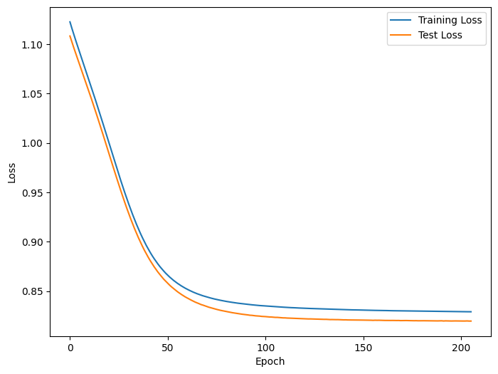

```python
do_training = True
if do_training == True:

    # Define the model, loss function and optimizer

    optimizer = optim.Adam(params=model.parameters(), lr=lr,  betas=(0.9, 0.999), eps=1e-07, weight_decay=0)
    loss_fn = nn.CrossEntropyLoss(reduction='sum')

    # Define lists to store losses
    train_losses = []
    test_losses = []

    # Initialize early stopping counter
    counter = 0
    best_loss = np.inf  # Set initial loss to infinity

    # Training loop
    for epoch in range(nEpoch):
        running_loss = 0.0
        for inputs, labels in train_loader:
            # Zero the gradients
            optimizer.zero_grad()

            # Forward pass
            outputs = model(inputs)

            # Compute the loss
            loss = loss_fn(outputs, labels)

            # Backward pass and optimization
            loss.backward()
            optimizer.step()

            # Update running loss
            running_loss += loss.item() # Log-likelihood on the training set

        # Evaluate on the test set
        test_loss = evaluate(model, loss_fn, test_loader) # Log-likelihood on the test set

        # Print status every 'status' epochs or epoch 0
        if epoch == 0 or (epoch + 1) % status == 0:
            print(f'Epoch [{epoch+1:5.0f}/{nEpoch}], Train Loss: {running_loss:0.3f}, Test Loss: {test_loss:0.3f}')

        # Store losses
        train_losses.append(running_loss)
        test_losses.append(test_loss)

        # Implement early stopping
        if test_loss < best_loss:
            best_loss = test_loss
            counter = 0
        else:
            counter += 1
            if counter >= patience:
                print(f'Early stopping at epoch {epoch+1}')
                break

    print(f'\nTraining finished.\tTrain Loss: {running_loss:0.3f}, Test Loss: {test_loss:0.3f}')
    show_loss_plot(train_losses, test_losses,num_obs_train, num_obs_test)
```

## `Exercise 2: Training the MLP model`

`A` Compare the performance on the test set of the MLP with the benchmark MNL. Has it (much) improved? What does this tell us?  
`B` Retrain the MLP using the following architectures: {hidden_size1,hidden_size2} = {1,1}, {3,3}, {1,20}, {20,1}, {20,3}, {20,20}  
`C` Does increasing the number of nodes lead to better generalisation performance (i.e. higher LL_test)? What is happening?  
`D` Explain why {1,1} and either {20,1} and {1,20} lead to a poor performance.  
`E` Retrain your model with a smaller and larger learning rate: lr = 0.01 and lr = 0.00001. Use {hidden_size1,hidden_size2} = {5,5}. Explain what is happening.

#### `Answers`

`A` .

`B`  
{1,1} gives a poor generalisation performance: LL = ~-1590  
{3,3} gives an okay generalisation performance: LL = ~-1400  
{1,20} gives a poor generalisation performance: LL = ~-1500  
{20,1} gives an poor generalisation performance: LL = ~-1500  
{20,3} gives an okay generalisation performance: LL = ~-1400

`C`

`D`

`E`

## `Exercise 3: Adding the socio-demographic features`

In Section 1 under `iv. Conversion to tensors` we choose to use only the features of the alternatives as inputs (i.e. `features_alt`), while in lab session 1 we saw that at least gender (`WOMAN`) and the residential city (`RESPCITY`) have some eplanatory power.

`A` Modify the code in this cell so that also these socio demographic features are used. Then, retrain the MLP.  
`B` Perhaps counter to your expectations, the model performance does not increase much. What does this tell us about:

1. the explanatory power of socio-demographics to the residential location choice, and
2. the ability of MLP models to learn subtle interaction effects?

#### `Answers`

`A.i` Redefine the tensor and dimension of the MLP model to include the new variables.

```python
do_exercise3 = False
if do_exercise3 == True:
    #### Recreate tensors for the train set ####

    #In this case, we use the characteristics of the alternatives 'features_alt', WOMAN and RESPCITY.
    selected_features = features_alt + ['WOMAN_1', 'RESPCITY_2', 'RESPCITY_3', 'RESPCITY_4']

    x_train_tensor = torch.tensor(x_train_scaled[selected_features].values, dtype=torch.float)
    y_train_dummy_tensor = torch.tensor(y_train_dummy, dtype=torch.float)

    x_test_tensor = torch.tensor(x_test_scaled[selected_features].values, dtype=torch.float)
    y_test_dummy_tensor = torch.tensor(y_test_dummy, dtype=torch.float)



    #### Recreate DataLoader ####
    dataset_train = TensorDataset(x_train_tensor, y_train_dummy_tensor)
    train_loader = DataLoader(dataset_train, batch_size=250, shuffle=True)

    dataset_test = TensorDataset(x_test_tensor, y_test_dummy_tensor)
    test_loader = DataLoader(dataset_test, batch_size=len(x_test_tensor), shuffle=True)



    #### Redefine the dimension of the MLP  ####
    input_size   = x_train_tensor.size()[1]  # Number of input features
    hidden_size1 = 20                        # Number of units in first hidden layer
    hidden_size2 = 20                        # Number of units in second hidden layer
    output_size  = 3                         # Number of output classes (determined by the number of alternatives)
```

`A.ii` Retrain the MLP model using the same cell as above:

Train Loss: 6035.490, Test Loss: 1384.504

`B.1`

`B.2`

## `4. The L-MNL model`

Next, we will build and train a hybrid model, namely the L-MNL model. This model combines an interpretable part following the assumptions of the MNL model and a neural network that processes the rest of the variables that we do not want to interpret. More specifically, we want the **flexibility** of the MLP but still want to get out an **estimate of the willingness to pay to reduce the walking distance to the grocery stores, expressed in terms of distance to the public transport**.

The figure below conceptually shows this model:

[figure not shown]

`i. Define the L-MNL model`  
To create the L-MNL model,we create a new class using PyTorch's nn.Module.

```python
class LMNL(nn.Module):
    def __init__(self, input_size_mlp, hidden_size1, hidden_size2,output_size):
        super(LMNL,self).__init__()

        # Create betas for the MNL part
        self.B_transport = nn.Linear(1, 1, bias=False )
        self.B_stores   = nn.Linear(1, 1, bias=False )

        # Create the hidden layers for the MLP part
        self.linear1 = nn.Linear(input_size_mlp, hidden_size1, bias=False)
        self.linear2 = nn.Linear(hidden_size1,   hidden_size2, bias=False)
        self.linear3 = nn.Linear(hidden_size2,   output_size,  bias=False)

    def forward(self, X_MNL, X_MLP):

        # Utility functions for the MNL part
        V_A = self.B_transport(X_MNL[:,0].unsqueeze(1))  + self.B_stores(X_MNL[:,1].unsqueeze(1))
        V_B = self.B_transport(X_MNL[:,2].unsqueeze(1))  + self.B_stores(X_MNL[:,3].unsqueeze(1))
        V_C = self.B_transport(X_MNL[:,4].unsqueeze(1))  + self.B_stores(X_MNL[:,5].unsqueeze(1))

        # Concatenating tensors to maintain the output dimension
        V_MNL = torch.cat((V_A, V_B, V_C), dim=1)

        # The MLP part
        X_MLP = torch.tanh(self.linear1(X_MLP)) # tanh activation function for the 1st layer
        X_MLP = torch.tanh(self.linear2(X_MLP)) # tanh activation function for the 2nd layer
        V_MLP = self.linear3(X_MLP)             # linear activation function for the output layer

        # Sum the utilities from the MNL and MLP parts
        V = V_MNL + V_MLP
        return V
```

`ii. Prepare the data for training the L-MNL model`  
We need to split the features going into the MLP and MNL parts. Because we want to compute the WTP of stores over transport. Therefore, the features related to transport and stores go into the MNL part, while the other features, including socio-demographics, go into the MLP part. **Importantly**, the MNL features must NOT be scaled.

```python
# Create dataframe with features for MNL part
features_mnl = ['TRANSPORT1', 'STORES1','TRANSPORT2', 'STORES2','TRANSPORT3', 'STORES3']
x_mnl_train = x_train[features_mnl]
x_mnl_test  = x_test[features_mnl]

print('Shape of x_mnl_train\t', x_mnl_train.shape)
print('Shape of x_mnl_test\t', x_mnl_test.shape)

# Create dataframe with features for MLP part
features_mlp_alt = ['FOREIGN1', 'CITY1', 'NOISE1', 'GREEN1',
                    'FOREIGN2', 'CITY2', 'NOISE2', 'GREEN2',
                    'FOREIGN3', 'CITY3', 'NOISE3', 'GREEN3']


features_socio = ['RESPCITY_2','RESPCITY_3','RESPCITY_4']
x_mlp_train = x_train_scaled[features_mlp_alt + features_socio]
x_mlp_test  = x_test_scaled[features_mlp_alt + features_socio]

print('\nShape of x_mlp_train\t', x_mlp_train.shape)
print('Shape of x_mlp_test\t', x_mlp_test.shape)
```

```
Shape of x_mnl_train	 (7300, 6)
Shape of x_mnl_test	 (1692, 6)

Shape of x_mlp_train	 (7300, 15)
Shape of x_mlp_test	 (1692, 15)
```

Convert data to PyTorch tensors

```python
# train
x_mnl_train_tensor = torch.tensor(x_mnl_train.values, dtype=torch.float)
x_mlp_train_tensor = torch.tensor(x_mlp_train.values, dtype=torch.float)
y_train_dummy_tensor = torch.tensor(y_train_dummy,    dtype=torch.float)

# test
x_mnl_test_tensor = torch.tensor(x_mnl_test.values, dtype=torch.float)
x_mlp_test_tensor = torch.tensor(x_mlp_test.values, dtype=torch.float)
y_test_dummy_tensor = torch.tensor(y_test_dummy,    dtype=torch.float)

print('Size of the X_mnl_train tensor = ', x_mnl_train_tensor.size())
print('Size of the X_mlp_train tensor = ', x_mlp_train_tensor.size())
print('\nSize of the X_mnl_test tensor  = ', x_mnl_test_tensor.size())
print('Size of the X_mlp_test tensor  = ', x_mlp_test_tensor.size())
```

```
Size of the X_mnl_train tensor =  torch.Size([7300, 6])
Size of the X_mlp_train tensor =  torch.Size([7300, 15])

Size of the X_mnl_test tensor  =  torch.Size([1692, 6])
Size of the X_mlp_test tensor  =  torch.Size([1692, 15])
```

Create PyTorch DataLoaders

```python
# Create a DataLoader for the train set
dataset_train_lmnl = TensorDataset(x_mnl_train_tensor, x_mlp_train_tensor, y_train_dummy_tensor)
train_loader_lmnl = DataLoader(dataset_train_lmnl, batch_size=250, shuffle=True)

# Create a DataLoader for the test set
dataset_test_lmnl = TensorDataset(x_mnl_test_tensor, x_mlp_test_tensor, y_test_dummy_tensor)
test_loader_lmnl = DataLoader(dataset_test_lmnl, batch_size=len(x_test_tensor), shuffle=False)
```

`iii. Define functions`  
We cannot re-use the evaluation function we created before, because this model takes two inputs (x_mnl, x_mlp), instead of one. Therefore, we create a new one for the L-MNL model.

```python
def evaluate_lmnl(model, criterion, data_loader):
    model.eval()  # Set the model to evaluation mode
    total_loss = 0.0

    with torch.no_grad():
        for x_mnl, x_mlp, labels in data_loader:
            outputs = model(x_mnl,x_mlp)
            loss = criterion(outputs, labels)
            total_loss += loss.item()

    return total_loss
```

`iv. Create the L-MNL model object`

```python
# Define the dimensions
input_size_mnl = x_mnl_train_tensor.size()[1]  # Number of input features
input_size_mlp = x_mlp_train_tensor.size()[1]  # Number of input features
hidden_size1 = 10  # Number of units in first hidden layer
hidden_size2 = 10  # Number of units in second hidden layer
output_size = 3    # Number of output classes
print(f' input_size_mnl = {input_size_mnl}, input_size_mlp = {input_size_mlp}, hidden_size1 = {hidden_size1}, hidden_size2 = {hidden_size2}, output_size = {output_size}')
```

```
 input_size_mnl = 6, input_size_mlp = 15, hidden_size1 = 10, hidden_size2 = 10, output_size = 3
```

```python
# Invoke the L-MNL model
model = LMNL(input_size_mlp, hidden_size1, hidden_size2, output_size)

# Print the model architecture
print_model_summary(model)
```

```
=== Model Summary ===
Layer: B_transport.weight  |	 Weights: 1
Layer: B_stores.weight     |	 Weights: 1
Layer: linear1.weight      |	 Weights: 150
Layer: linear2.weight      |	 Weights: 100
Layer: linear3.weight      |	 Weights: 30

Total trainable Weights: 282

=== Layers ===
Linear(in_features=1, out_features=1, bias=False)
Linear(in_features=1, out_features=1, bias=False)
Linear(in_features=15, out_features=10, bias=False)
Linear(in_features=10, out_features=10, bias=False)
Linear(in_features=10, out_features=3, bias=False)
```

`v. Train the L-MNL model`  
Finally, we are ready to train the L-MNL model!

```python
# Define training settings
nEpoch = 1000  # Set the number of epochs
lr = 0.0001  # Set the learning rate
status = 10  # Print status every 'status' epochs
patience = 5  # Number of epochs to wait before early stopping
```

```
Epoch [    1/1000], Train Loss: 23386.205, Test Loss: 5418.249
Epoch [   10/1000], Train Loss: 21886.747, Test Loss: 5067.016
Epoch [   20/1000], Train Loss: 20218.586, Test Loss: 4676.410
Epoch [   30/1000], Train Loss: 18480.986, Test Loss: 4269.341
Epoch [   40/1000], Train Loss: 16676.966, Test Loss: 3846.277
Epoch [   50/1000], Train Loss: 14858.325, Test Loss: 3418.608
Epoch [   60/1000], Train Loss: 13085.811, Test Loss: 3001.809
Epoch [   70/1000], Train Loss: 11445.496, Test Loss: 2616.542
Epoch [   80/1000], Train Loss: 10048.011, Test Loss: 2290.537
Epoch [   90/1000], Train Loss: 8968.956, Test Loss: 2038.958
Epoch [  100/1000], Train Loss: 8190.102, Test Loss: 1857.507
Epoch [  110/1000], Train Loss: 7642.109, Test Loss: 1728.980
Epoch [  120/1000], Train Loss: 7247.378, Test Loss: 1636.619
Epoch [  130/1000], Train Loss: 6952.796, Test Loss: 1568.355
Epoch [  140/1000], Train Loss: 6727.293, Test Loss: 1517.314
Epoch [  150/1000], Train Loss: 6552.077, Test Loss: 1478.404
Epoch [  160/1000], Train Loss: 6416.512, Test Loss: 1449.597
Epoch [  170/1000], Train Loss: 6313.753, Test Loss: 1428.267
Epoch [  180/1000], Train Loss: 6237.749, Test Loss: 1413.451
Epoch [  190/1000], Train Loss: 6183.701, Test Loss: 1403.279
Epoch [  200/1000], Train Loss: 6146.506, Test Loss: 1396.960
Epoch [  210/1000], Train Loss: 6121.327, Test Loss: 1392.879
Epoch [  220/1000], Train Loss: 6104.729, Test Loss: 1390.701
Epoch [  230/1000], Train Loss: 6093.129, Test Loss: 1389.469
Epoch [  240/1000], Train Loss: 6084.883, Test Loss: 1388.760
Epoch [  250/1000], Train Loss: 6078.695, Test Loss: 1388.338
Epoch [  260/1000], Train Loss: 6073.621, Test Loss: 1387.799
Epoch [  270/1000], Train Loss: 6069.574, Test Loss: 1387.608
Early stopping at epoch 273

Training finished.	Train Loss: 6068.316, Test Loss: 1387.528
```

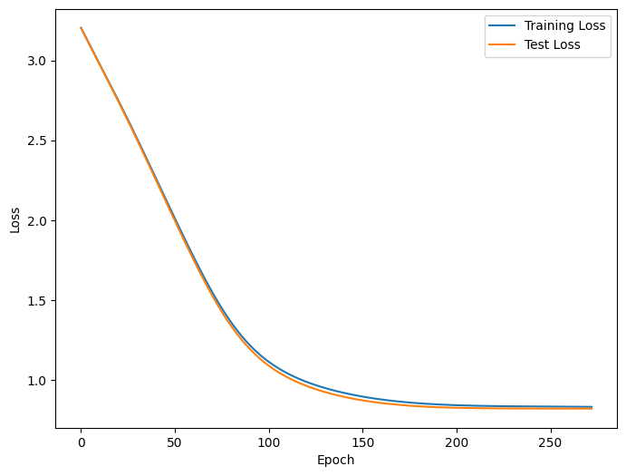

```python
# Define the loss function and optimizer
loss_fn = nn.CrossEntropyLoss(reduction='sum')
optimizer = optim.Adam(params=model.parameters(), lr=lr,  betas=(0.9, 0.999), eps=1e-07, weight_decay=0)

# Define lists to store losses
train_losses = []
test_losses = []

# Initialize early stopping counter
counter = 0
best_loss = np.inf  # Set initial loss to infinity

# Training loop
for epoch in range(nEpoch):
    running_loss = 0.0
    for x_mnl, x_mlp, labels in train_loader_lmnl:

        # Zero the gradients
        optimizer.zero_grad()

        # Forward pass
        outputs = model(x_mnl,x_mlp)

        # Compute the loss
        loss = loss_fn(outputs, labels)

        # Backward pass and optimization
        loss.backward()
        optimizer.step()

        # Update running loss
        running_loss += loss.item() # Log-likelihood on the training set

    # Evaluate on the test set
    test_loss = evaluate_lmnl(model, loss_fn, test_loader_lmnl)

    # Print status every 'status' epochs or epoch 0
    if epoch == 0 or (epoch + 1) % status == 0:
        print(f'Epoch [{epoch+1:5.0f}/{nEpoch}], Train Loss: {running_loss:0.3f}, Test Loss: {test_loss:0.3f}')

    # Store losses
    train_losses.append(running_loss)
    test_losses.append(test_loss)

    # Implement early stopping
    if test_loss < best_loss:
        best_loss = test_loss
        counter = 0
    else:
        counter += 1
        if counter >= patience:
            print(f'Early stopping at epoch {epoch+1}')
            break

print(f'\nTraining finished.\tTrain Loss: {running_loss:0.3f}, Test Loss: {test_loss:0.3f}')
show_loss_plot(train_losses, test_losses, num_obs_train, num_obs_test)
```

```python
# Compute the Willingness to pay to reduce the distance to the grovery store by one minute
LL_LMNL = best_loss
B_transport_LMNL = model.B_transport.weight.data.item()
B_stores_LMNL = model.B_stores.weight.data.item()

WTP_LMNL = B_stores_LMNL/B_transport_LMNL
print(f'\nWillingness to pay to reduce one minute of walking time to the grocery store is: {WTP_LMNL:.2f} walking minutes to the public transport')
```

```
Willingness to pay to reduce one minute of walking time to the grocery store is: 1.15 walking minutes to the public transport
```

## `Exercise 4: Features MLP`

`A` Try reducing the number of features that are feed into the MLP and assess the impact on the model performance and WTP.  
E.g. only use `RESPCITY` and `WOMAN`, as in lab session 1 we saw these variables had a significant impact

#### `Answers`

`A.i` Redefine the tensor and dimension of the MLP model to include the new variables.

```python
do_exercise4 = False
if do_exercise4 == True:
    #### Recreate tensors for the train set ####

    #In this case, we only have to modify the variables that will go into the MLP model:
    features_socio = ['WOMAN_1', 'RESPCITY_2', 'RESPCITY_3', 'RESPCITY_4']

    x_mlp_train = x_train_scaled[features_mlp_alt + features_socio]
    x_mlp_test  = x_test_scaled[features_mlp_alt + features_socio]

    x_mlp_train_tensor = torch.tensor(x_mlp_train.values, dtype=torch.float)
    x_mlp_test_tensor = torch.tensor(x_mlp_test.values, dtype=torch.float)


    #### Recreate DataLoader ####
    dataset_train_lmnl = TensorDataset(x_mnl_train_tensor, x_mlp_train_tensor, y_train_dummy_tensor)
    train_loader_lmnl = DataLoader(dataset_train_lmnl, batch_size=250, shuffle=True)
    dataset_test_lmnl = TensorDataset(x_mnl_test_tensor, x_mlp_test_tensor, y_test_dummy_tensor)
    test_loader_lmnl = DataLoader(dataset_test_lmnl, batch_size=len(x_test_tensor), shuffle=False)


    #### Redefine the dimension of the MLP  ####
    input_size_mlp = x_mlp_train_tensor.size()[1]  # Number of input features
```

`A.ii` Retrain the MLP model using the same cell as above:

Train Loss: 6019.589, Test Loss: 1378.459 and the Willingness to pay to reduce one minute of walking time to the grocery store is: 1.02 walking minutes to the public transport

## `Exercise 5: Forecasting using L-MNL`

Suppose that a researcher would like to use this model to make forecasts for Zurich (as we did in Lab session 1). However, this is more challenging.

`A` Give 2 reasons why making forecasts using the L-MNL model is less straightforward than using the MNL models  
`B` Give 2 arguments in favour of using the L-MNL model for informing the municipality of Zurich about the impacts of the planned redevelopment on the residential demand per neighbourhood.  
`C` Suppose that you are hired to assist and advise this researcher. What would you advise in terms of e.g. the specification of the L-MNL model, training, benchmarking, etc.